# Seurat HBCA Workshop

## Step 9. Annotate cell clusters

Clustering the cells gives a identity label to each cell, and we can assume that cells with the same label are similar to each other and therefore can be seen to be of the same cell type or cell state. The next question is which exact cell types or cell states these cell clusters are representing. This is not an easy question to answer, and usually there is no perfect answer. There are several options one can try to resolve this issue. For instance, 1. Check the expression of canonical cell type and cell state markers in these clusters; 2. Identify signature genes, or marker genes, of each identified cell cluster. Based on the identified cluster marker genes, one can do literature search, enrichment analysis or do experiment (or ask people around) for annotation; 3. For each cluster, compare its gene expression profile with existing reference data.

```r
# find markers for every cluster compared to all remaining cells, report only the positive ones
hbca.markers <- FindAllMarkers(hbca, only.pos = TRUE, min.pct = 0.25, logfc.threshold = 0.25)
hbca.markers %>% group_by(cluster) %>% top_n(n = 2, wt = avg_log2FC)
```

| p_val | avg_log2FC | pct.1 | pct.2 | p_val_adj | cluster | gene |
| --- | --- | --- | --- | --- | --- | --- |
| 0.000000e+00 | 5.614183 | 0.373 | 0.029 | 0.000000e+00 | 0 | PTGDS |
| 0.000000e+00 | 5.533277 | 0.369 | 0.033 | 0.000000e+00 | 0 | TAC1 |
| 0.000000e+00 | 4.435366 | 0.873 | 0.086 | 0.000000e+00 | 1 | CCL28 |
| 0.000000e+00 | 4.720861 | 0.278 | 0.008 | 0.000000e+00 | 1 | FAM3D |
| 0.000000e+00 | 6.074602 | 0.658 | 0.016 | 0.000000e+00 | 2 | ANKRD30A |
| 0.000000e+00 | 6.179998 | 0.306 | 0.003 | 0.000000e+00 | 2 | AC008703.1 |
| 0.000000e+00 | 7.873734 | 0.676 | 0.010 | 0.000000e+00 | 3 | CD2 |
| 0.000000e+00 | 7.930216 | 0.364 | 0.005 | 0.000000e+00 | 3 | KLRB1 |
| 0.000000e+00 | 7.904448 | 0.306 | 0.002 | 0.000000e+00 | 4 | MYCT1 |
| 0.000000e+00 | 8.100150 | 0.283 | 0.003 | 0.000000e+00 | 4 | MECOM |

[output cut: 10 more lines]

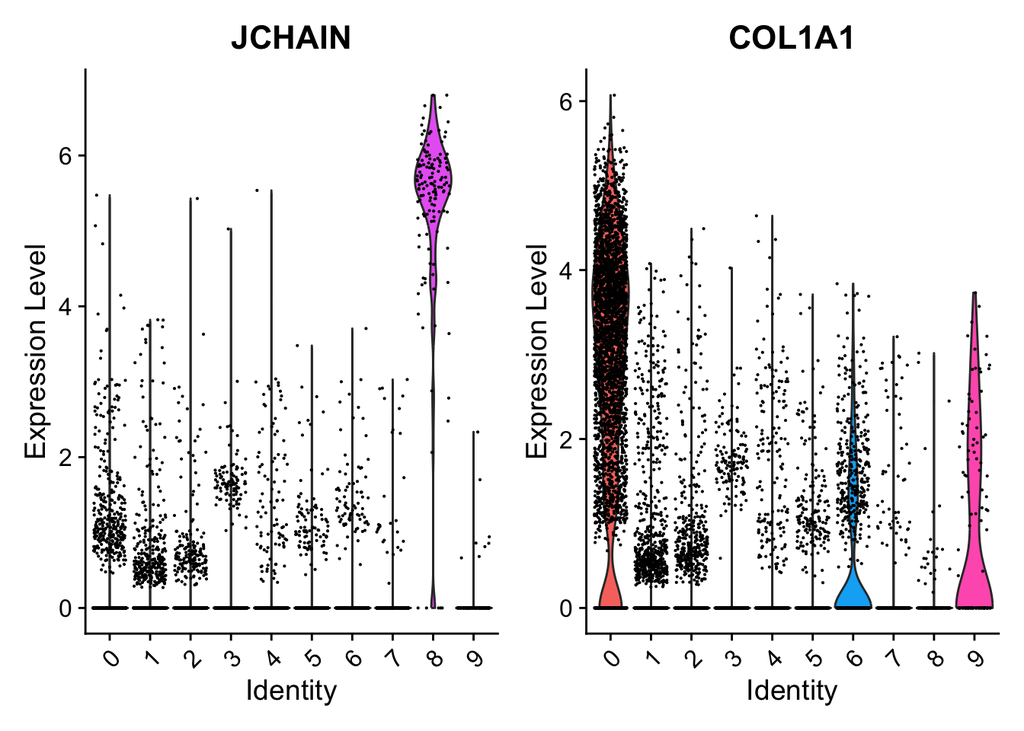

```r
#plots for DE genes
VlnPlot(hbca, features = c("JCHAIN", "COL1A1"))
```

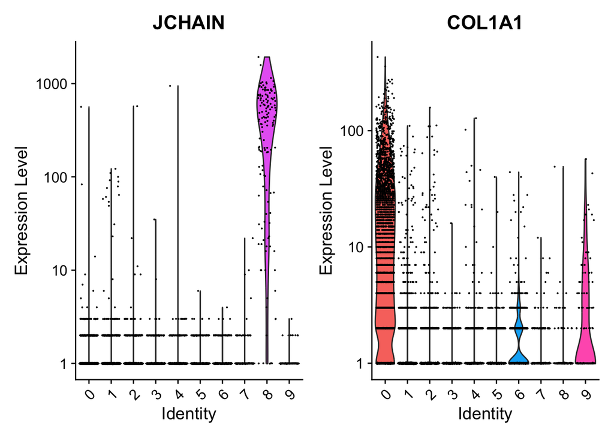

```r
# you can plot raw counts as well
VlnPlot(hbca, features = c("JCHAIN", "COL1A1"), slot = "counts", log = TRUE)
```

### Markers for Breast Tissue

```r
library(knitr)

# Create a mini example table
df <- data.frame(celltype = c("Fibroblast", "LumHR", "LumSec", "Pericytes", "Plasma Bcells", "Endo-venous", "Myoepi", "Bcells", "Tcells"),marker_gene = c("COL1A1", "ANKRD30A", "KRT23", "RGS5", "JCHAIN", "SELE", "KRT14", "HLA-DRA", "LEPROTL1" ))

# Print as a nicely formatted table in R Markdown
kable(df)
```

| celltype | marker_gene |
| --- | --- |
| Fibroblast | COL1A1 |
| LumHR | ANKRD30A |
| LumSec | KRT23 |
| Pericytes | RGS5 |
| Plasma Bcells | JCHAIN |
| Endo-venous | SELE |
| Myoepi | KRT14 |
| Bcells | HLA-DRA |
| Tcells | LEPROTL1 |

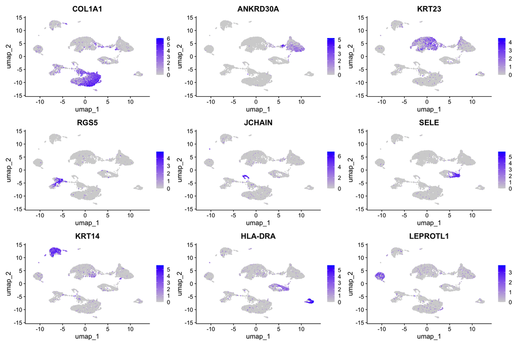

```r
FeaturePlot(hbca, features = c("COL1A1", "ANKRD30A", "KRT23", "RGS5", "JCHAIN", "SELE", "KRT14", "HLA-DRA", "LEPROTL1" ))
```

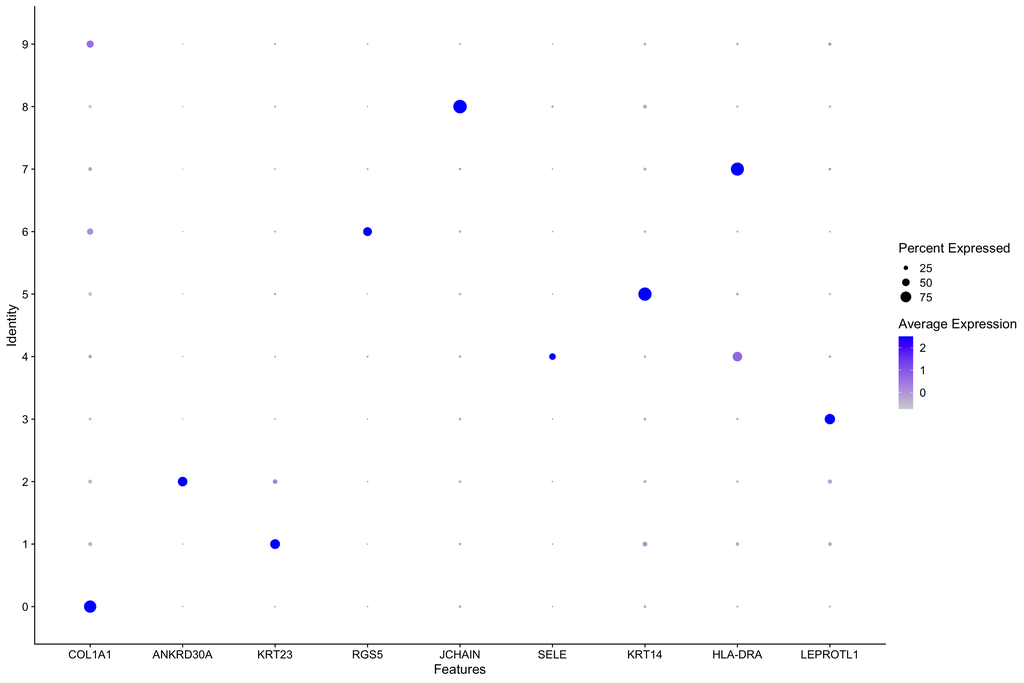

```r
#plots for DE genes
DotPlot(hbca, features = c("COL1A1", "ANKRD30A", "KRT23", "RGS5", "JCHAIN", "SELE", "KRT14", "HLA-DRA", "LEPROTL1" ))
```

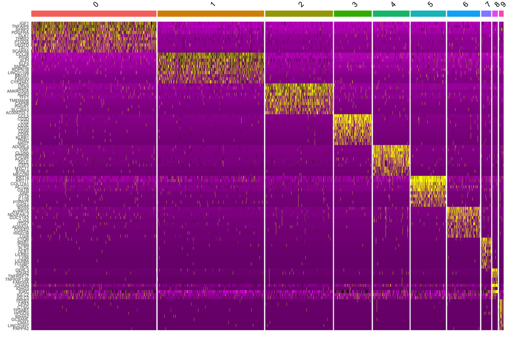

```r
#heatmap of top marker genes
top10 <- hbca.markers %>% group_by(cluster) %>% top_n(n = 10, wt = avg_log2FC)
DoHeatmap(hbca, features = top10$gene) + NoLegend()
```

```r
# assign cell type labels to clusters
new.cluster.ids <- c("Fibroblast", "LumSec", "LumHR","Tcells" ,"Endothelial","myoepi","pericytes","Bcells","plasmaBcells","Fibroblast")

names(new.cluster.ids) <- levels(hbca)
hbca <- RenameIdents(hbca, new.cluster.ids)
plot_manual<- DimPlot(hbca, reduction = "umap", label = TRUE, pt.size = 0.5)
```

### For each cluster, compare its gene expression profile with existing reference data.

```r
ref <- celldex::BlueprintEncodeData()
singleR_input <- GetAssayData(hbca, assay = "RNA", slot = "data")
```

```r
# Load singleR directory
library(SingleR)

# Run SingleR annotation function
hpca_main_cluster <- SingleR(test = singleR_input,
                                              ref = ref,
                                              labels = ref$label.main,
                                              clusters = hbca@meta.data$seurat_clusters)
hbca$singleR_hpca_main <- hpca_main_cluster$labels[match((hbca@meta.data$seurat_clusters), rownames(hpca_main_cluster))]
plot_automated <- DimPlot(hbca, label = TRUE, repel = TRUE, reduction = "umap", group.by = "singleR_hpca_main")
```

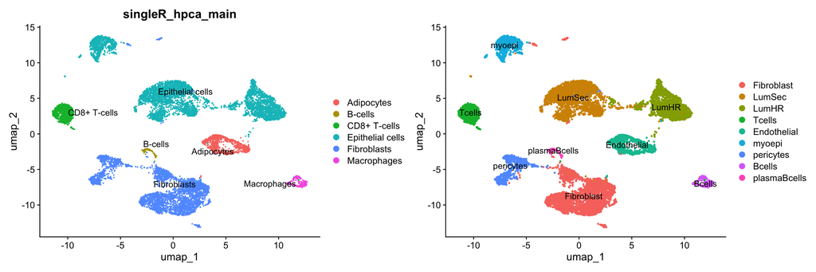

```r
plot_automated + plot_manual
```

```r
end_time <- Sys.time()
total_time <- end_time - start_time
print(paste("Total execution time:", total_time))
```

```
## [1] "Total execution time: 3.26377121607463"
```